# Optimal Treatment Analysis

## Outcome Variable

**Outcome Variable:** haz

## Predictor Variables

**Intervention Variable:** exclfeed6

**Adjustment Set:**

- arm
- sex
- W_mage
- meducyrs
- feducyrs
- hhwealth_quart
- hfoodsec
- W_mhtcm
- vagbrth
- W_gagebrth
- W_birthwt
- W_birthlen
- W_nrooms
- W_nchldlt5
- month
- brthmon
- W_parity
- impfloor
- impsan
- safeh20
- delta_W_mage
- delta_meducyrs
- delta_feducyrs
- delta_hhwealth_quart
- delta_hfoodsec
- delta_W_mhtcm
- delta_vagbrth
- delta_W_gagebrth
- delta_W_birthwt
- delta_W_birthlen
- delta_W_nrooms
- delta_W_nchldlt5
- delta_month
- delta_brthmon
- delta_W_parity
- delta_impfloor
- delta_impsan
- delta_safeh20

## Stratifying Variables

The analysis was stratified on these variable(s):

- agecat
- studyid
- country

## Data Summary

| agecat | studyid | country | exclfeed6 | n_cell | n |
| --- | --- | --- | --- | --- | --- |
| Birth | ki0047075b-MAL-ED | BANGLADESH | 1 | 56 | 231 |
| Birth | ki0047075b-MAL-ED | BANGLADESH | 0 | 175 | 231 |
| Birth | ki0047075b-MAL-ED | BRAZIL | 1 | 12 | 175 |
| Birth | ki0047075b-MAL-ED | BRAZIL | 0 | 163 | 175 |
| Birth | ki0047075b-MAL-ED | INDIA | 1 | 5 | 190 |
| Birth | ki0047075b-MAL-ED | INDIA | 0 | 185 | 190 |
| Birth | ki0047075b-MAL-ED | NEPAL | 1 | 11 | 170 |
| Birth | ki0047075b-MAL-ED | NEPAL | 0 | 159 | 170 |
| Birth | ki0047075b-MAL-ED | PERU | 1 | 10 | 256 |
| Birth | ki0047075b-MAL-ED | PERU | 0 | 246 | 256 |
| Birth | ki0047075b-MAL-ED | SOUTH AFRICA | 1 | 0 | 211 |
| Birth | ki0047075b-MAL-ED | SOUTH AFRICA | 0 | 211 | 211 |
| Birth | ki0047075b-MAL-ED | TANZANIA, UNITED REPUBLIC OF | 1 | 1 | 119 |
| Birth | ki0047075b-MAL-ED | TANZANIA, UNITED REPUBLIC OF | 0 | 118 | 119 |
| Birth | ki1000108-CMC-V-BCS-2002 | INDIA | 1 | 7 | 7 |
| Birth | ki1000108-CMC-V-BCS-2002 | INDIA | 0 | 0 | 7 |
| Birth | ki1000108-IRC | INDIA | 1 | 0 | 14 |
| Birth | ki1000108-IRC | INDIA | 0 | 14 | 14 |
| Birth | ki1000109-EE | PAKISTAN | 1 | 1 | 2 |
| Birth | ki1000109-EE | PAKISTAN | 0 | 1 | 2 |
| Birth | ki1000304b-SAS-CompFeed | INDIA | 1 | 48 | 50 |
| Birth | ki1000304b-SAS-CompFeed | INDIA | 0 | 2 | 50 |
| Birth | ki1101329-Keneba | GAMBIA | 1 | 484 | 1401 |
| Birth | ki1101329-Keneba | GAMBIA | 0 | 917 | 1401 |
| Birth | kiGH5241-JiVitA-3 | BANGLADESH | 1 | 15068 | 19082 |
| Birth | kiGH5241-JiVitA-3 | BANGLADESH | 0 | 4014 | 19082 |
| Birth | kiGH5241-JiVitA-4 | BANGLADESH | 1 | 617 | 767 |
| Birth | kiGH5241-JiVitA-4 | BANGLADESH | 0 | 150 | 767 |
| 6 months | ki0047075b-MAL-ED | BANGLADESH | 1 | 57 | 235 |
| 6 months | ki0047075b-MAL-ED | BANGLADESH | 0 | 178 | 235 |

[output cut: 64 more lines]

The following strata were considered:

- agecat: 24 months, studyid: ki0047075b-MAL-ED, country: BANGLADESH
- agecat: 24 months, studyid: ki0047075b-MAL-ED, country: BRAZIL
- agecat: 24 months, studyid: ki0047075b-MAL-ED, country: INDIA
- agecat: 24 months, studyid: ki0047075b-MAL-ED, country: NEPAL
- agecat: 24 months, studyid: ki0047075b-MAL-ED, country: PERU
- agecat: 24 months, studyid: ki0047075b-MAL-ED, country: SOUTH AFRICA
- agecat: 24 months, studyid: ki0047075b-MAL-ED, country: TANZANIA, UNITED REPUBLIC OF
- agecat: 24 months, studyid: ki1000108-CMC-V-BCS-2002, country: INDIA
- agecat: 24 months, studyid: ki1000108-IRC, country: INDIA
- agecat: 24 months, studyid: ki1017093b-PROVIDE, country: BANGLADESH
- agecat: 24 months, studyid: ki1101329-Keneba, country: GAMBIA
- agecat: 24 months, studyid: ki1113344-GMS-Nepal, country: NEPAL
- agecat: 24 months, studyid: ki1148112-LCNI-5, country: MALAWI
- agecat: 24 months, studyid: kiGH5241-JiVitA-3, country: BANGLADESH
- agecat: 24 months, studyid: kiGH5241-JiVitA-4, country: BANGLADESH
- agecat: 6 months, studyid: ki0047075b-MAL-ED, country: BANGLADESH
- agecat: 6 months, studyid: ki0047075b-MAL-ED, country: BRAZIL
- agecat: 6 months, studyid: ki0047075b-MAL-ED, country: INDIA
- agecat: 6 months, studyid: ki0047075b-MAL-ED, country: NEPAL
- agecat: 6 months, studyid: ki0047075b-MAL-ED, country: PERU
- agecat: 6 months, studyid: ki0047075b-MAL-ED, country: SOUTH AFRICA
- agecat: 6 months, studyid: ki0047075b-MAL-ED, country: TANZANIA, UNITED REPUBLIC OF
- agecat: 6 months, studyid: ki1000108-CMC-V-BCS-2002, country: INDIA
- agecat: 6 months, studyid: ki1000108-IRC, country: INDIA
- agecat: 6 months, studyid: ki1000109-EE, country: PAKISTAN
- agecat: 6 months, studyid: ki1000304b-SAS-CompFeed, country: INDIA
- agecat: 6 months, studyid: ki1000304b-SAS-FoodSuppl, country: INDIA
- agecat: 6 months, studyid: ki1017093b-PROVIDE, country: BANGLADESH
- agecat: 6 months, studyid: ki1101329-Keneba, country: GAMBIA
- agecat: 6 months, studyid: ki1113344-GMS-Nepal, country: NEPAL
- agecat: 6 months, studyid: ki1148112-LCNI-5, country: MALAWI
- agecat: 6 months, studyid: kiGH5241-JiVitA-3, country: BANGLADESH
- agecat: 6 months, studyid: kiGH5241-JiVitA-4, country: BANGLADESH
- agecat: Birth, studyid: ki0047075b-MAL-ED, country: BANGLADESH
- agecat: Birth, studyid: ki0047075b-MAL-ED, country: BRAZIL
- agecat: Birth, studyid: ki0047075b-MAL-ED, country: INDIA
- agecat: Birth, studyid: ki0047075b-MAL-ED, country: NEPAL
- agecat: Birth, studyid: ki0047075b-MAL-ED, country: PERU
- agecat: Birth, studyid: ki0047075b-MAL-ED, country: SOUTH AFRICA
- agecat: Birth, studyid: ki0047075b-MAL-ED, country: TANZANIA, UNITED REPUBLIC OF
- agecat: Birth, studyid: ki1000108-CMC-V-BCS-2002, country: INDIA
- agecat: Birth, studyid: ki1000108-IRC, country: INDIA
- agecat: Birth, studyid: ki1000109-EE, country: PAKISTAN
- agecat: Birth, studyid: ki1000304b-SAS-CompFeed, country: INDIA
- agecat: Birth, studyid: ki1101329-Keneba, country: GAMBIA
- agecat: Birth, studyid: kiGH5241-JiVitA-3, country: BANGLADESH
- agecat: Birth, studyid: kiGH5241-JiVitA-4, country: BANGLADESH

### Dropped Strata

Some strata were dropped due to rare outcomes:

- agecat: Birth, studyid: ki0047075b-MAL-ED, country: SOUTH AFRICA
- agecat: Birth, studyid: ki0047075b-MAL-ED, country: TANZANIA, UNITED REPUBLIC OF
- agecat: Birth, studyid: ki1000108-CMC-V-BCS-2002, country: INDIA
- agecat: Birth, studyid: ki1000108-IRC, country: INDIA
- agecat: Birth, studyid: ki1000109-EE, country: PAKISTAN
- agecat: Birth, studyid: ki1000304b-SAS-CompFeed, country: INDIA
- agecat: 6 months, studyid: ki0047075b-MAL-ED, country: SOUTH AFRICA
- agecat: 6 months, studyid: ki0047075b-MAL-ED, country: TANZANIA, UNITED REPUBLIC OF
- agecat: 6 months, studyid: ki1000108-CMC-V-BCS-2002, country: INDIA
- agecat: 6 months, studyid: ki1000108-IRC, country: INDIA
- agecat: 6 months, studyid: ki1000304b-SAS-FoodSuppl, country: INDIA
- agecat: 24 months, studyid: ki0047075b-MAL-ED, country: SOUTH AFRICA
- agecat: 24 months, studyid: ki0047075b-MAL-ED, country: TANZANIA, UNITED REPUBLIC OF
- agecat: 24 months, studyid: ki1000108-CMC-V-BCS-2002, country: INDIA
- agecat: 24 months, studyid: ki1000108-IRC, country: INDIA

## Methods Detail

We’re interested in the causal parameters $E[Y_a]$ for all values of $a \in \mathcal{A}$. These parameters represent the mean outcome if, possibly contrary to fact, we intervened to set all units to have $A=a$. Under the randomization and positivity assumptions, these are identified by the statistical parameters $\psi_a=E_W[E_{Y|A,W}(Y|A=a,W)]$. In addition, we’re interested in the mean of $Y$, $E[Y]$ under no intervention (the observed mean). We will estimate these parameters by using SuperLearner to fit the relevant likelihood factors – $E_{Y|A,W}(Y|A=a,W)$ and $p(A=a|W)$, and then updating our likelihood fit using a joint TMLE.

For unadjusted analyses ($W=\{\}$), initial likelihoods were estimated using Lrnr_glm to estimate the simple $E(Y|A)$ and Lrnr_mean to estimate $p(A)$. For adjusted analyses, a small library containing Lrnr_glmnet, Lrnr_xgboost, and Lrnr_mean was used.

Having estimated these parameters, we will then use the delta method to estimate relative risks and attributable risks relative to a prespecified baseline level of $A$.

# Results Detail

## Results Plots

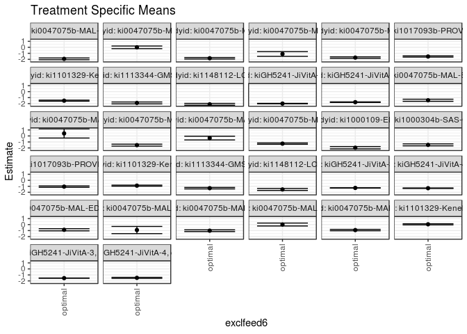

## Results Table

### Parameter: TSM

| agecat | studyid | country | intervention_level | baseline_level | estimate | ci_lower | ci_upper |
| --- | --- | --- | --- | --- | --- | --- | --- |
| Birth | ki0047075b-MAL-ED | BANGLADESH | optimal | observed | -0.8674021 | -1.0441486 | -0.6906557 |
| Birth | ki0047075b-MAL-ED | BRAZIL | optimal | observed | -0.9083982 | -1.5097353 | -0.3070611 |
| Birth | ki0047075b-MAL-ED | INDIA | optimal | observed | -1.0162615 | -1.1637642 | -0.8687588 |
| Birth | ki0047075b-MAL-ED | NEPAL | optimal | observed | 0.0135465 | -0.2268463 | 0.2539393 |
| Birth | ki0047075b-MAL-ED | PERU | optimal | observed | -0.9147882 | -1.0312945 | -0.7982820 |
| Birth | ki1101329-Keneba | GAMBIA | optimal | observed | 0.0476925 | -0.0412040 | 0.1365891 |
| Birth | kiGH5241-JiVitA-3 | BANGLADESH | optimal | observed | -1.5365225 | -1.5595973 | -1.5134476 |
| Birth | kiGH5241-JiVitA-4 | BANGLADESH | optimal | observed | -1.4933077 | -1.5822004 | -1.4044151 |
| 6 months | ki0047075b-MAL-ED | BANGLADESH | optimal | observed | -1.4384155 | -1.6158291 | -1.2610019 |
| 6 months | ki0047075b-MAL-ED | BRAZIL | optimal | observed | 0.4201927 | -0.3453880 | 1.1857733 |
| 6 months | ki0047075b-MAL-ED | INDIA | optimal | observed | -1.5333816 | -1.7005392 | -1.3662240 |
| 6 months | ki0047075b-MAL-ED | NEPAL | optimal | observed | -0.3506887 | -0.6619048 | -0.0394726 |
| 6 months | ki0047075b-MAL-ED | PERU | optimal | observed | -1.2789306 | -1.3874970 | -1.1703641 |
| 6 months | ki1000109-EE | PAKISTAN | optimal | observed | -1.9636789 | -2.1561792 | -1.7711785 |
| 6 months | ki1000304b-SAS-CompFeed | INDIA | optimal | observed | -1.4877061 | -1.6531098 | -1.3223023 |
| 6 months | ki1017093b-PROVIDE | BANGLADESH | optimal | observed | -1.0579546 | -1.1752885 | -0.9406207 |
| 6 months | ki1101329-Keneba | GAMBIA | optimal | observed | -0.8974635 | -0.9853221 | -0.8096048 |
| 6 months | ki1113344-GMS-Nepal | NEPAL | optimal | observed | -1.3209843 | -1.4446229 | -1.1973456 |
| 6 months | ki1148112-LCNI-5 | MALAWI | optimal | observed | -1.5259856 | -1.6951194 | -1.3568518 |
| 6 months | kiGH5241-JiVitA-3 | BANGLADESH | optimal | observed | -1.2762729 | -1.3012466 | -1.2512992 |
| 6 months | kiGH5241-JiVitA-4 | BANGLADESH | optimal | observed | -1.3226529 | -1.3670174 | -1.2782884 |
| 24 months | ki0047075b-MAL-ED | BANGLADESH | optimal | observed | -1.9239711 | -2.0695224 | -1.7784198 |
| 24 months | ki0047075b-MAL-ED | BRAZIL | optimal | observed | -0.0023725 | -0.2234872 | 0.2187421 |
| 24 months | ki0047075b-MAL-ED | INDIA | optimal | observed | -1.8270970 | -1.9536190 | -1.7005750 |
| 24 months | ki0047075b-MAL-ED | NEPAL | optimal | observed | -1.1147169 | -1.5066358 | -0.7227981 |
| 24 months | ki0047075b-MAL-ED | PERU | optimal | observed | -1.7154228 | -1.8375803 | -1.5932653 |
| 24 months | ki1017093b-PROVIDE | BANGLADESH | optimal | observed | -1.5335528 | -1.6390591 | -1.4280465 |
| 24 months | ki1101329-Keneba | GAMBIA | optimal | observed | -1.5076437 | -1.5926858 | -1.4226017 |
| 24 months | ki1113344-GMS-Nepal | NEPAL | optimal | observed | -1.8857152 | -2.0445096 | -1.7269208 |
| 24 months | ki1148112-LCNI-5 | MALAWI | optimal | observed | -2.1139818 | -2.2660541 | -1.9619095 |
| 24 months | kiGH5241-JiVitA-3 | BANGLADESH | optimal | observed | -1.9921154 | -2.0318300 | -1.9524009 |
| 24 months | kiGH5241-JiVitA-4 | BANGLADESH | optimal | observed | -1.7582630 | -1.8000818 | -1.7164442 |

### Parameter: E(Y)

| agecat | studyid | country | intervention_level | baseline_level | estimate | ci_lower | ci_upper |
| --- | --- | --- | --- | --- | --- | --- | --- |
| Birth | ki0047075b-MAL-ED | BANGLADESH | observed | observed | -1.0317316 | -1.1618799 | -0.9015833 |
| Birth | ki0047075b-MAL-ED | BRAZIL | observed | observed | -0.7263429 | -0.8876385 | -0.5650472 |
| Birth | ki0047075b-MAL-ED | INDIA | observed | observed | -1.0250526 | -1.1724135 | -0.8776918 |
| Birth | ki0047075b-MAL-ED | NEPAL | observed | observed | -0.6964706 | -0.8552823 | -0.5376589 |
| Birth | ki0047075b-MAL-ED | PERU | observed | observed | -0.9311719 | -1.0458986 | -0.8164451 |
| Birth | ki1101329-Keneba | GAMBIA | observed | observed | 0.0162027 | -0.0517648 | 0.0841702 |
| Birth | kiGH5241-JiVitA-3 | BANGLADESH | observed | observed | -1.5502914 | -1.5696478 | -1.5309349 |
| Birth | kiGH5241-JiVitA-4 | BANGLADESH | observed | observed | -1.5207432 | -1.6058630 | -1.4356233 |
| 6 months | ki0047075b-MAL-ED | BANGLADESH | observed | observed | -1.2140355 | -1.3320337 | -1.0960372 |
| 6 months | ki0047075b-MAL-ED | BRAZIL | observed | observed | 0.0510207 | -0.0930194 | 0.1950608 |
| 6 months | ki0047075b-MAL-ED | INDIA | observed | observed | -1.2193606 | -1.3390323 | -1.0996890 |
| 6 months | ki0047075b-MAL-ED | NEPAL | observed | observed | -0.5595745 | -0.6727496 | -0.4463993 |
| 6 months | ki0047075b-MAL-ED | PERU | observed | observed | -1.3092999 | -1.4165606 | -1.2020392 |
| 6 months | ki1000109-EE | PAKISTAN | observed | observed | -2.2004704 | -2.3234073 | -2.0775336 |
| 6 months | ki1000304b-SAS-CompFeed | INDIA | observed | observed | -1.4697236 | -1.6333919 | -1.3060553 |
| 6 months | ki1017093b-PROVIDE | BANGLADESH | observed | observed | -1.0871041 | -1.1635539 | -1.0106543 |
| 6 months | ki1101329-Keneba | GAMBIA | observed | observed | -0.9331108 | -0.9823173 | -0.8839043 |
| 6 months | ki1113344-GMS-Nepal | NEPAL | observed | observed | -1.3352045 | -1.4146382 | -1.2557708 |
| 6 months | ki1148112-LCNI-5 | MALAWI | observed | observed | -1.6395956 | -1.7592633 | -1.5199278 |
| 6 months | kiGH5241-JiVitA-3 | BANGLADESH | observed | observed | -1.3104400 | -1.3338132 | -1.2870668 |
| 6 months | kiGH5241-JiVitA-4 | BANGLADESH | observed | observed | -1.3574771 | -1.3964060 | -1.3185482 |
| 24 months | ki0047075b-MAL-ED | BANGLADESH | observed | observed | -1.9532775 | -2.0781247 | -1.8284303 |
| 24 months | ki0047075b-MAL-ED | BRAZIL | observed | observed | 0.0418343 | -0.1253834 | 0.2090521 |
| 24 months | ki0047075b-MAL-ED | INDIA | observed | observed | -1.8466071 | -1.9736347 | -1.7195796 |
| 24 months | ki0047075b-MAL-ED | NEPAL | observed | observed | -1.2744493 | -1.3952297 | -1.1536689 |
| 24 months | ki0047075b-MAL-ED | PERU | observed | observed | -1.7294949 | -1.8488722 | -1.6101177 |
| 24 months | ki1017093b-PROVIDE | BANGLADESH | observed | observed | -1.5861179 | -1.6693668 | -1.5028689 |
| 24 months | ki1101329-Keneba | GAMBIA | observed | observed | -1.5721046 | -1.6251725 | -1.5190368 |
| 24 months | ki1113344-GMS-Nepal | NEPAL | observed | observed | -1.8951389 | -1.9810871 | -1.8091907 |
| 24 months | ki1148112-LCNI-5 | MALAWI | observed | observed | -1.9605820 | -2.1001715 | -1.8209925 |
| 24 months | kiGH5241-JiVitA-3 | BANGLADESH | observed | observed | -2.0122091 | -2.0399540 | -1.9844641 |
| 24 months | kiGH5241-JiVitA-4 | BANGLADESH | observed | observed | -1.7762003 | -1.8148628 | -1.7375378 |

### Parameter: PAR

| agecat | studyid | country | intervention_level | baseline_level | estimate | ci_lower | ci_upper |
| --- | --- | --- | --- | --- | --- | --- | --- |
| Birth | ki0047075b-MAL-ED | BANGLADESH | optimal | observed | -0.1643295 | -0.3202707 | -0.0083882 |
| Birth | ki0047075b-MAL-ED | BRAZIL | optimal | observed | 0.1820553 | -0.3861344 | 0.7502451 |
| Birth | ki0047075b-MAL-ED | INDIA | optimal | observed | -0.0087911 | -0.0432120 | 0.0256298 |
| Birth | ki0047075b-MAL-ED | NEPAL | optimal | observed | -0.7100171 | -0.9810189 | -0.4390152 |
| Birth | ki0047075b-MAL-ED | PERU | optimal | observed | -0.0163837 | -0.0420109 | 0.0092436 |
| Birth | ki1101329-Keneba | GAMBIA | optimal | observed | -0.0314898 | -0.0947237 | 0.0317441 |
| Birth | kiGH5241-JiVitA-3 | BANGLADESH | optimal | observed | -0.0137689 | -0.0266070 | -0.0009309 |
| Birth | kiGH5241-JiVitA-4 | BANGLADESH | optimal | observed | -0.0274354 | -0.0643989 | 0.0095281 |
| 6 months | ki0047075b-MAL-ED | BANGLADESH | optimal | observed | 0.2243800 | 0.0797684 | 0.3689916 |
| 6 months | ki0047075b-MAL-ED | BRAZIL | optimal | observed | -0.3691719 | -1.0977440 | 0.3594001 |
| 6 months | ki0047075b-MAL-ED | INDIA | optimal | observed | 0.3140210 | 0.1890208 | 0.4390211 |
| 6 months | ki0047075b-MAL-ED | NEPAL | optimal | observed | -0.2088858 | -0.5097211 | 0.0919495 |
| 6 months | ki0047075b-MAL-ED | PERU | optimal | observed | -0.0303693 | -0.0711749 | 0.0104362 |
| 6 months | ki1000109-EE | PAKISTAN | optimal | observed | -0.2367916 | -0.3849897 | -0.0885934 |
| 6 months | ki1000304b-SAS-CompFeed | INDIA | optimal | observed | 0.0179824 | -0.0394213 | 0.0753861 |
| 6 months | ki1017093b-PROVIDE | BANGLADESH | optimal | observed | -0.0291495 | -0.1211016 | 0.0628027 |
| 6 months | ki1101329-Keneba | GAMBIA | optimal | observed | -0.0356473 | -0.1068178 | 0.0355231 |
| 6 months | ki1113344-GMS-Nepal | NEPAL | optimal | observed | -0.0142203 | -0.0988839 | 0.0704434 |
| 6 months | ki1148112-LCNI-5 | MALAWI | optimal | observed | -0.1136100 | -0.2401860 | 0.0129660 |
| 6 months | kiGH5241-JiVitA-3 | BANGLADESH | optimal | observed | -0.0341671 | -0.0445589 | -0.0237752 |
| 6 months | kiGH5241-JiVitA-4 | BANGLADESH | optimal | observed | -0.0348242 | -0.0639421 | -0.0057064 |
| 24 months | ki0047075b-MAL-ED | BANGLADESH | optimal | observed | -0.0293064 | -0.1164153 | 0.0578025 |
| 24 months | ki0047075b-MAL-ED | BRAZIL | optimal | observed | 0.0442068 | -0.1093470 | 0.1977606 |
| 24 months | ki0047075b-MAL-ED | INDIA | optimal | observed | -0.0195101 | -0.0501204 | 0.0111002 |
| 24 months | ki0047075b-MAL-ED | NEPAL | optimal | observed | -0.1597324 | -0.5448675 | 0.2254027 |
| 24 months | ki0047075b-MAL-ED | PERU | optimal | observed | -0.0140721 | -0.0375342 | 0.0093899 |
| 24 months | ki1017093b-PROVIDE | BANGLADESH | optimal | observed | -0.0525650 | -0.1157866 | 0.0106566 |
| 24 months | ki1101329-Keneba | GAMBIA | optimal | observed | -0.0644609 | -0.1349038 | 0.0059820 |
| 24 months | ki1113344-GMS-Nepal | NEPAL | optimal | observed | -0.0094237 | -0.1419400 | 0.1230926 |
| 24 months | ki1148112-LCNI-5 | MALAWI | optimal | observed | 0.1533998 | 0.0450153 | 0.2617842 |
| 24 months | kiGH5241-JiVitA-3 | BANGLADESH | optimal | observed | -0.0200937 | -0.0477517 | 0.0075644 |
| 24 months | kiGH5241-JiVitA-4 | BANGLADESH | optimal | observed | -0.0179373 | -0.0358825 | 0.0000079 |